# Comparative Analysis of Model Performance for Coffee Discrimination Using Hyperspectral Imaging and Machine Learning: Impact of Preprocessing and Variable Selection

Author

Derick Malavi

## Introduction

This document evaluates the performance of various classification models in detecting Arabica coffee adulteration with Robusta. The analysis focuses on key factors affecting model performance, including:

```
- The type of classification model used.
- Variable or wavelength selection methods, such as Boruta and Genetic Algorithms (GA).
- The impact of spectral preprocessing techniques.
- Comparison of models trained on balanced versus imbalanced datasets.
```

The models assessed in this study include Linear Discriminant Analysis (LDA), k-Nearest Neighbors (KNN), Support Vector Machines (SVM), Random Forest (RF), Neural Networks, and ensemble methods. The ensemble models were constructed using a stacking approach, where all the individual models served as base learners, and Random Forest acted as the meta-learner. Model performance was evaluated using the Matthews Correlation Coefficient (MCC), a robust metric particularly suitable for imbalanced data sets.

## Load Packages

```r
suppressWarnings(suppressMessages({
  library(readxl)
  library(readr)
  library(tidyverse)
  library(car)
  library(PMCMRplus)
  library(ggplot2)
  library(tidyr)
  library(dplyr)
  library(skimr)
  library(janitor)
  library(lattice)
  library(dunn.test)
  library(ARTool)
  library(emmeans)
  library(ggpubr)
  library(readxl)
}))
```

## Part 1: Assess Model Performance (External Validation Set): Based on type of model, variable selection & spectral pre-processing

## Load and Visualize Data

```r
df <- read_excel('summary_model_results_classification_instant _coffee.xlsx',sheet = 'Model')

head(df)
```

```
# A tibble: 6 × 11
  Model Pre_processing Wav_Selec_Reduction Unbalanced_Data_MCC Balanced_Data_MCC
  <chr> <chr>          <chr>                             <dbl>             <dbl>
1 k-NN  Unprocessed    Full _Spectra_PCA                 -0.01              0.04
2 k-NN  SNV+SG+1D      Full _Spectra_PCA                  0.96              0.91
3 k-NN  SNV+SG+2D      Full _Spectra_PCA                  1                 1
4 k-NN  MSC+SG+1D      Full _Spectra_PCA                  0.94              0.9
5 k-NN  MSC+SG+2D      Full _Spectra_PCA                  1                 0.94
6 LDA   Unprocessed    Full _Spectra_PCA                 -0.01              0.4
# ℹ 6 more variables: Imb_Balanced_Accuracy <dbl>, Bal_Balanced_Accuracy <dbl>,
#   Imbal_Specificty <dbl>, Bal_Specificty <dbl>, Imbal_Sensitivity <dbl>,
#   Bal_Sensitivity <dbl>
```

```r
# Change the independent variables to factors

df$Model <- as.factor(df$Model)
df$Pre_processing <- as.factor(df$Pre_processing)
df$Wav_Selec_Reduction <- as.factor(df$Wav_Selec_Reduction)
df$Imb_Balanced_Accuracy <- as.numeric(df$Imb_Balanced_Accuracy)
df$Bal_Balanced_Accuracy <- as.numeric(df$Bal_Balanced_Accuracy)

# column names
colnames(df)
```

```
 [1] "Model"                 "Pre_processing"        "Wav_Selec_Reduction"
 [4] "Unbalanced_Data_MCC"   "Balanced_Data_MCC"     "Imb_Balanced_Accuracy"
 [7] "Bal_Balanced_Accuracy" "Imbal_Specificty"      "Bal_Specificty"
[10] "Imbal_Sensitivity"     "Bal_Sensitivity"
```

## Check Distribution Using Histograms

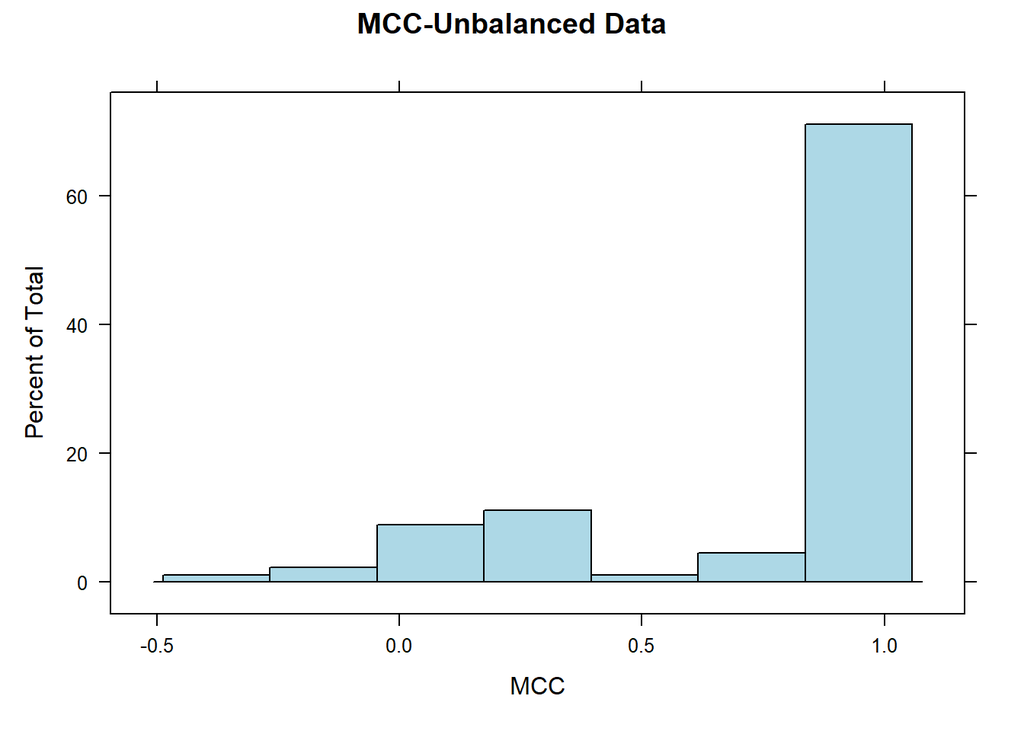

```r
# Unbalanced data
histogram(df$Unbalanced_Data_MCC,
          main = 'MCC-Unbalanced Data', xlab = 'MCC',
          cex.main = 1,col = 'lightblue')
```

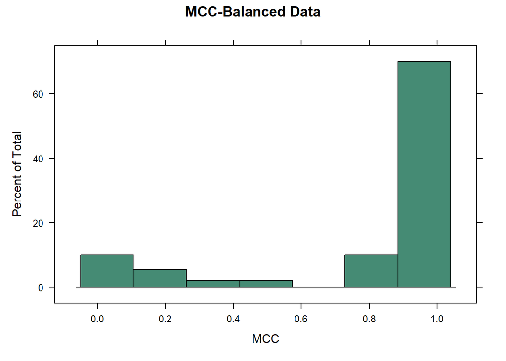

```r
histogram(~Balanced_Data_MCC, data = df,
          main = 'MCC-Balanced Data',xlab = 'MCC',
          cex.main = 0.4, col = 'aquamarine4')
```

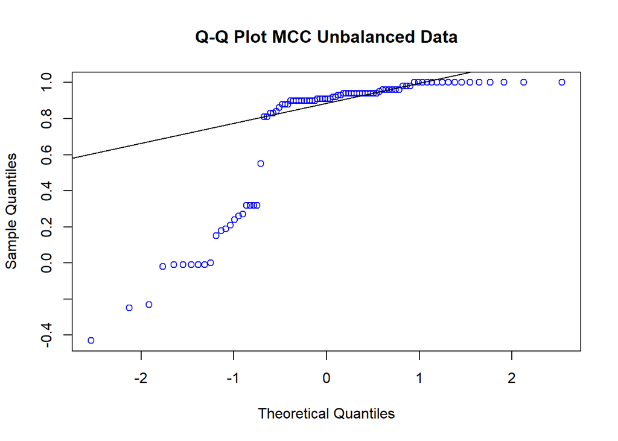

```r
qqnorm(df$Unbalanced_Data_MCC,
       main = 'Q-Q Plot MCC Unbalanced Data', col = "blue") # Unbalanced Data
qqline(df$Unbalanced_Data_MCC)
```

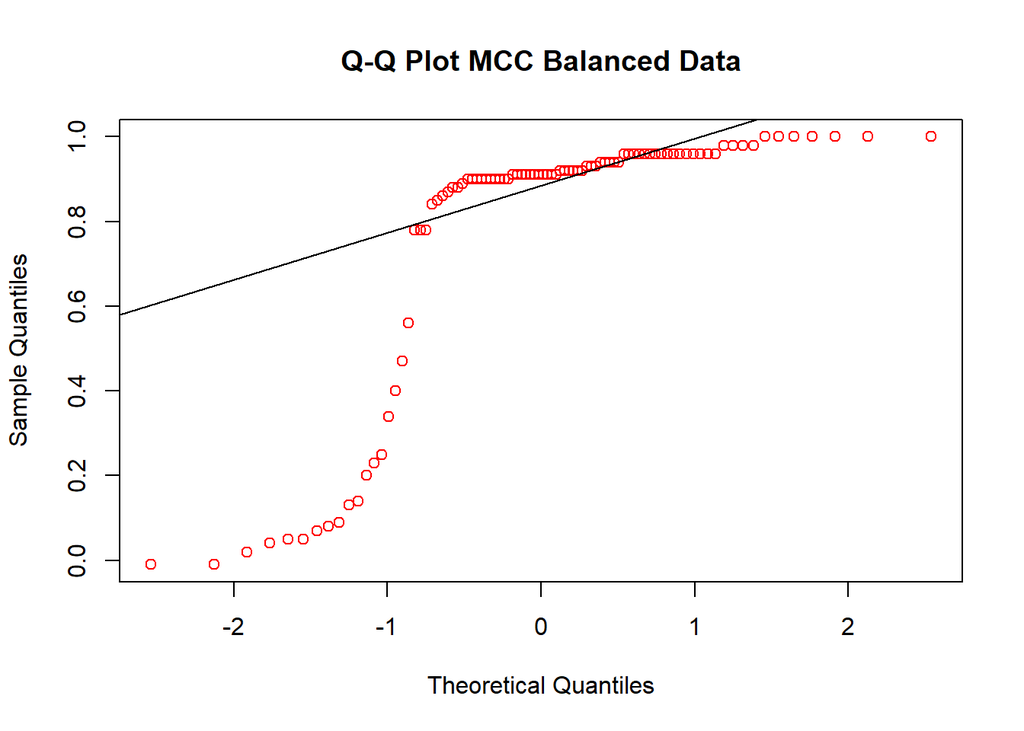

```r
qqnorm(df$Balanced_Data_MCC,
       main = 'Q-Q Plot MCC Balanced Data', col = "red") # Unbalanced Data
qqline(df$Unbalanced_Data_MCC)
```

- Based on the histograms and quantile plots, the data is not normally distributed. This can be verified further by the **Shapiro- Wilke Test**.

## Test for Normality

```r
shapiro.test(df$Unbalanced_Data_MCC) # for imbalanced data
```

```
    Shapiro-Wilk normality test

data:  df$Unbalanced_Data_MCC
W = 0.68694, p-value = 1.479e-12
```

```r
shapiro.test(df$Balanced_Data_MCC) # Balanced Data
```

```
    Shapiro-Wilk normality test

data:  df$Balanced_Data_MCC
W = 0.63568, p-value = 1.295e-13
```

```r
# Run ANOVA and check the normality of residuals # Unbalanced Data
aov_model_1 <- aov(Unbalanced_Data_MCC~Model, data = df)

# Check assumptions
shapiro.test(residuals(aov_model_1))  # Normality
```

```
    Shapiro-Wilk normality test

data:  residuals(aov_model_1)
W = 0.73769, p-value = 2.206e-11
```

```r
leveneTest(Unbalanced_Data_MCC~Model, data = df)  # Variance homogeneity
```

```
Levene's Test for Homogeneity of Variance (center = median)
      Df F value Pr(>F)
group  5  0.9884 0.4298
      84
```

```r
## Balanced (SMOTE)
aov_model_2 <- aov(Balanced_Data_MCC~Model, data = df)
shapiro.test(residuals(aov_model_2))  # Normality
```

```
    Shapiro-Wilk normality test

data:  residuals(aov_model_2)
W = 0.66067, p-value = 4.111e-13
```

```r
leveneTest(Balanced_Data_MCC~Model, data = df)
```

```
Levene's Test for Homogeneity of Variance (center = median)
      Df F value Pr(>F)
group  5   0.333 0.8917
      84
```

```r
colnames(df)
```

```
 [1] "Model"                 "Pre_processing"        "Wav_Selec_Reduction"
 [4] "Unbalanced_Data_MCC"   "Balanced_Data_MCC"     "Imb_Balanced_Accuracy"
 [7] "Bal_Balanced_Accuracy" "Imbal_Specificty"      "Bal_Specificty"
[10] "Imbal_Sensitivity"     "Bal_Sensitivity"
```

- The results of the Shapiro-Wilk test (for the residuals) are statistically significant (p < 0.05), providing strong evidence against the assumption of normality. This indicates that the data are not normally distribute. We will therefore consider non-parametric alternatives!

## Check Performance based on Type of Model

- This section investigates the models k-NN, LDA, SVM, NNET, Random Forest and stacked models

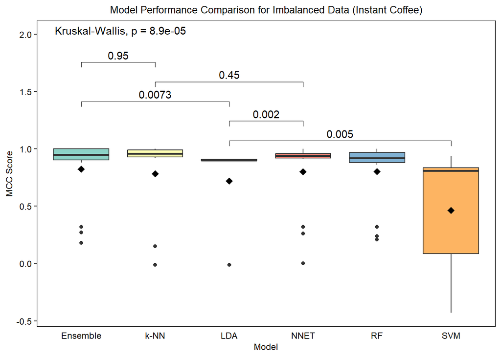

```r
# Visualize with box plots
my_comparisons <- list(c('SVM','LDA'),c('NNET','LDA'),c('Ensemble','LDA'),
                       c('NNET','k-NN'),c('Ensemble','k-NN'))


# Imbalanced Data

ggplot(data = df, aes(x = Model, y = Unbalanced_Data_MCC))+
  geom_boxplot(aes(fill = Model))+
  labs(title = 'Model Performance Comparison for Imbalanced Data (Instant Coffee)')+
  ylab('MCC Score')+
  theme_bw()+
  theme(
    axis.title.x = element_text(color = "black", size = 9),
    axis.text.x = element_text(color = "black", size = 9),
    axis.ticks.x = element_blank(),
    axis.text.y = element_text(color = "black", size = 9),
    axis.title.y = element_text(color = "black", size = 9),
    panel.grid = element_blank(),
    plot.title = element_text(hjust = 0.5, color = 'black', size = 10),
    legend.position = 'none'
  )+
  scale_fill_brewer(palette = "Set3", name = 'Model')+
  stat_summary(fun=mean, geom="point", shape=18, size=3, color="black")+
  stat_compare_means(comparisons = my_comparisons)+
  stat_compare_means(label.y = max(df$Unbalanced_Data_MCC) * 2)
```

```r
ggsave("Model_No_SMOTE.png", width = 6, height = 4, dpi = 600, bg = "white")
```

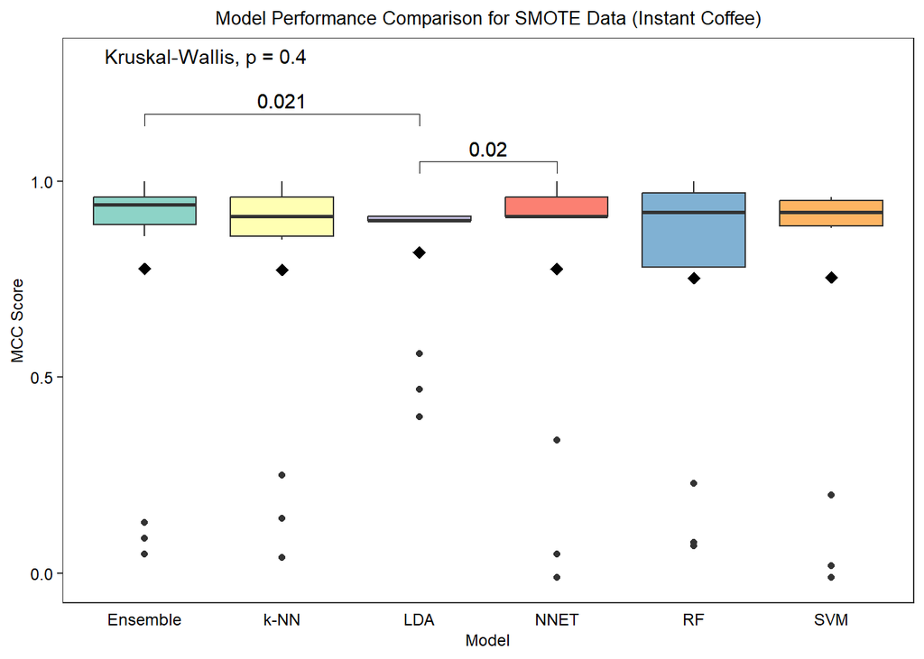

```r
# Balanced Data

# Visualize with box plots
my_comparisons <- list(c('NNET','LDA'),
                       c('Ensemble', 'LDA')
                       )



# Imbalanced Data

ggplot(data = df, aes(x = Model, y = Balanced_Data_MCC))+
  geom_boxplot(aes(fill = Model))+
  labs(title = 'Model Performance Comparison for SMOTE Data (Instant Coffee)')+
  ylab('MCC Score')+
  theme_bw()+
  theme(
    axis.title.x = element_text(color = "black", size = 9),
    axis.text.x = element_text(color = "black", size = 9),
    axis.ticks.x = element_blank(),
    axis.text.y = element_text(color = "black", size = 9),
    axis.title.y = element_text(color = "black", size = 9),
    plot.title = element_text(hjust = 0.5, color = 'black', size = 10),
    panel.grid = element_blank(),
    legend.position = 'none'
  )+
  scale_fill_brewer(palette = "Set3", name = 'Model')+
  stat_summary(fun=mean, geom="point", shape=18, size=3, color="black")+
  stat_compare_means(comparisons = my_comparisons)+
  stat_compare_means(comparisons = my_comparisons)+
  stat_compare_means(label.y = max(df$Balanced_Data_MCC) * 1.3)
```

```r
ggsave("Model_SMOTE.png", width = 6, height = 4, dpi = 600, bg = "white")
```

```r
spec <- df %>% dplyr::select(Model,Bal_Specificty) %>% group_by(Model) %>%
  summarise(Mean_Specificity = mean(Bal_Specificty)) %>% arrange(Mean_Specificity)
spec
```

```
# A tibble: 6 × 2
  Model    Mean_Specificity
  <fct>               <dbl>
1 RF                   77.0
2 SVM                  78.0
3 Ensemble             80.0
4 k-NN                 83.2
5 NNET                 85.2
6 LDA                  91.1
```